# Gemma Portion

Gemma Clark

Fall 2020

State analyses, milk analyses (Grade A = milk, Grade B = cheese, yogurt, etc.) (milk fluid, state, milk_facts for the milk stuff, avoid cheese and butter stuff)

# Setup

```r
#install.packages('tidytuesdayR')
library(tidytuesdayR)
#install.packages('tidyverse')
library(tidyverse)
```

```r
#install.packages('ggplot2')
library(ggplot2)
#install.packages('ggpubr')
library(ggpubr)
#install.packages('usmap')
library(usmap)
#install.packages('plyr')
library(plyr)
#install.packages('data.table')
library(data.table)
#install.packages('knitr')
library(knitr)

dairy = tt_load(2019,5)
```

```
## --- Compiling #TidyTuesday Information for 2019-01-29 ----
```

```
## --- There are 5 files available ---
```

```
## --- Starting Download ---
```

```
## --- Download complete ---
```

```r
state_milk_production = dairy$state_milk_production
fluid_milk_sales = dairy$fluid_milk_sales
```

## Milk Production by State and Region

The ‘state_milk_production’ file contained four columns: region, state, year, and milk produced. The years ranged from 1970 to 2017 and the data included all 50 states. The states were divided into the following ten regions: Northeast (ME, NH, VT, MA, RI, CT, NY, NJ, PA, DE, MD); Lake States (MI, WI, MN); Corn Belt (OH, IN, IL, IA, MO); Northern Plains (ND, SD, NE, KS); Appalachian (VA, WV, NC, KY, TN); Southeast (SC, GA, FL, AL); Delta States (MS, AR, LA); Southern Plaines (OK, TX); Mountain (MT, ID, WY, CO, NM, AZ, UT, NV); and Pacific (WA, OR, CA, AK, HI).

### Summary Statistics and Boxplots of Milk Production by State and by Year

Here, I am calculating some summary statistics and boxplots for milk production by state and by year. These statistics include the mean, median, standard deviation, minimum, maximum, and sample size of each sub-group. This R chunk is used for calculating summary statistics by state.

```r
# Preparing summary statistics by state
prep = state_milk_production[,-1]
state_df = pivot_wider(prep, names_from = state, values_from = milk_produced)

state_stats = matrix(data = NA, nrow = (ncol(state_df) - 1), ncol = 6)
cols = c('mean', 'median', 'standard deviation', 'minimum', 'maximum', 'sample size')
colnames(state_stats) = cols
state_stats_rows = c()
j = 1

for (i in 2:(ncol(state_df))) {
  state_stats_rows = append(state_stats_rows, colnames(state_df)[i])
  state_stats_data = as.numeric(as.matrix(state_df[i]))
  state_stats[j, 'mean'] = mean(state_stats_data)
  state_stats[j, 'median'] = median(state_stats_data)
  state_stats[j, 'standard deviation'] = sd(state_stats_data)
  state_stats[j, 'minimum'] = min(state_stats_data)
  state_stats[j, 'maximum'] = max(state_stats_data)
  state_stats[j, 'sample size'] = length(state_stats_data)

  j = j + 1
}

rownames(state_stats) = state_stats_rows

# Summary Statistics Milk Production by State
kable(signif(state_stats, digits = 3), caption = 'Summary Statistics of Milk Production by State')
```

Summary Statistics of Milk Production by State

|  | mean | median | standard deviation | minimum | maximum | sample size |
| --- | --- | --- | --- | --- | --- | --- |
| Maine | 6.38e+08 | 6.34e+08 | 3.66e+07 | 5.74e+08 | 7.36e+08 | 48 |
| New Hampshire | 3.21e+08 | 3.24e+08 | 2.82e+07 | 2.72e+08 | 3.79e+08 | 48 |
| Vermont | 2.43e+09 | 2.50e+09 | 2.33e+08 | 1.94e+09 | 2.73e+09 | 48 |
| Massachusetts | 4.36e+08 | 4.52e+08 | 1.48e+08 | 2.11e+08 | 6.58e+08 | 48 |
| Rhode Island | 3.59e+07 | 3.30e+07 | 1.70e+07 | 1.30e+07 | 7.50e+07 | 48 |
| Connecticut | 5.12e+08 | 5.25e+08 | 1.04e+08 | 3.53e+08 | 6.61e+08 | 48 |
| New York | 1.17e+10 | 1.16e+10 | 1.18e+09 | 9.73e+09 | 1.49e+10 | 48 |
| New Jersey | 3.48e+08 | 3.41e+08 | 1.72e+08 | 1.19e+08 | 7.30e+08 | 48 |
| Pennsylvania | 9.70e+09 | 1.02e+10 | 1.34e+09 | 6.72e+09 | 1.12e+10 | 48 |
| Delaware | 1.27e+08 | 1.30e+08 | 1.84e+07 | 9.00e+07 | 1.59e+08 | 48 |
| Maryland | 1.33e+09 | 1.37e+09 | 2.25e+08 | 9.53e+08 | 1.62e+09 | 48 |
| Michigan | 6.21e+09 | 5.44e+09 | 1.78e+09 | 4.35e+09 | 1.12e+10 | 48 |
| Wisconsin | 2.34e+10 | 2.32e+10 | 2.80e+09 | 1.84e+10 | 3.03e+10 | 48 |
| Minnesota | 9.44e+09 | 9.42e+09 | 6.64e+08 | 8.10e+09 | 1.09e+10 | 48 |
| Ohio | 4.71e+09 | 4.59e+09 | 3.89e+08 | 4.22e+09 | 5.59e+09 | 48 |
| Indiana | 2.69e+09 | 2.34e+09 | 6.38e+08 | 2.17e+09 | 4.26e+09 | 48 |
| Illinois | 2.31e+09 | 2.40e+09 | 3.45e+08 | 1.81e+09 | 2.85e+09 | 48 |
| Iowa | 4.14e+09 | 4.04e+09 | 3.36e+08 | 3.69e+09 | 5.17e+09 | 48 |
| Missouri | 2.38e+09 | 2.71e+09 | 6.37e+08 | 1.24e+09 | 3.10e+09 | 48 |
| North Dakota | 7.63e+08 | 8.72e+08 | 2.81e+08 | 3.24e+08 | 1.12e+09 | 48 |
| South Dakota | 1.69e+09 | 1.65e+09 | 2.79e+08 | 1.29e+09 | 2.62e+09 | 48 |
| Nebraska | 1.27e+09 | 1.26e+09 | 1.54e+08 | 1.04e+09 | 1.61e+09 | 48 |
| Kansas | 1.78e+09 | 1.42e+09 | 6.68e+08 | 1.08e+09 | 3.50e+09 | 48 |
| Virginia | 1.87e+09 | 1.87e+09 | 1.29e+08 | 1.69e+09 | 2.15e+09 | 48 |
| West Virginia | 2.70e+08 | 2.74e+08 | 8.10e+07 | 1.27e+08 | 3.82e+08 | 48 |
| North Carolina | 1.32e+09 | 1.47e+09 | 2.89e+08 | 8.66e+08 | 1.75e+09 | 48 |
| Kentucky | 1.86e+09 | 2.06e+09 | 5.14e+08 | 1.00e+09 | 2.53e+09 | 48 |
| Tennessee | 1.63e+09 | 1.85e+09 | 5.63e+08 | 6.93e+08 | 2.33e+09 | 48 |
| South Carolina | 4.13e+08 | 4.08e+08 | 1.06e+08 | 2.47e+08 | 5.76e+08 | 48 |
| Georgia | 1.41e+09 | 1.40e+09 | 1.61e+08 | 1.16e+09 | 1.84e+09 | 48 |
| Florida | 2.22e+09 | 2.23e+09 | 2.45e+08 | 1.64e+09 | 2.62e+09 | 48 |
| Alabama | 4.33e+08 | 5.01e+08 | 2.22e+08 | 8.90e+07 | 8.20e+08 | 48 |
| Mississippi | 6.19e+08 | 7.34e+08 | 2.79e+08 | 1.37e+08 | 1.05e+09 | 48 |
| Arkansas | 5.43e+08 | 7.02e+08 | 2.70e+08 | 7.90e+07 | 8.48e+08 | 48 |
| Louisiana | 7.33e+08 | 8.90e+08 | 3.28e+08 | 1.60e+08 | 1.13e+09 | 48 |
| Oklahoma | 1.13e+09 | 1.18e+09 | 1.71e+08 | 6.92e+08 | 1.32e+09 | 48 |
| Texas | 5.82e+09 | 5.56e+09 | 2.41e+09 | 3.06e+09 | 1.21e+10 | 48 |
| Montana | 3.19e+08 | 3.14e+08 | 2.36e+07 | 2.75e+08 | 3.72e+08 | 48 |
| Idaho | 6.04e+09 | 3.49e+09 | 4.70e+09 | 1.49e+09 | 1.47e+10 | 48 |
| Wyoming | 1.13e+08 | 1.23e+08 | 2.47e+07 | 5.40e+07 | 1.40e+08 | 48 |
| Colorado | 1.80e+09 | 1.50e+09 | 9.66e+08 | 8.35e+08 | 4.19e+09 | 48 |
| New Mexico | 3.70e+09 | 3.05e+09 | 3.10e+09 | 3.04e+08 | 8.21e+09 | 48 |
| Arizona | 2.44e+09 | 2.00e+09 | 1.45e+09 | 5.85e+08 | 5.01e+09 | 48 |
| Utah | 1.43e+09 | 1.39e+09 | 4.27e+08 | 8.19e+08 | 2.22e+09 | 48 |
| Nevada | 3.95e+08 | 3.83e+08 | 1.86e+08 | 1.41e+08 | 7.09e+08 | 48 |
| Washington | 4.52e+09 | 5.09e+09 | 1.45e+09 | 2.09e+09 | 6.65e+09 | 48 |
| Oregon | 1.71e+09 | 1.63e+09 | 5.34e+08 | 9.70e+08 | 2.59e+09 | 48 |
| California | 2.54e+10 | 2.41e+10 | 1.17e+10 | 9.46e+09 | 4.23e+10 | 48 |
| Alaska | 1.41e+07 | 1.40e+07 | 6.86e+06 | 3.00e+06 | 3.50e+07 | 48 |
| Hawaii | 1.09e+08 | 1.36e+08 | 4.91e+07 | 1.90e+07 | 1.60e+08 | 48 |

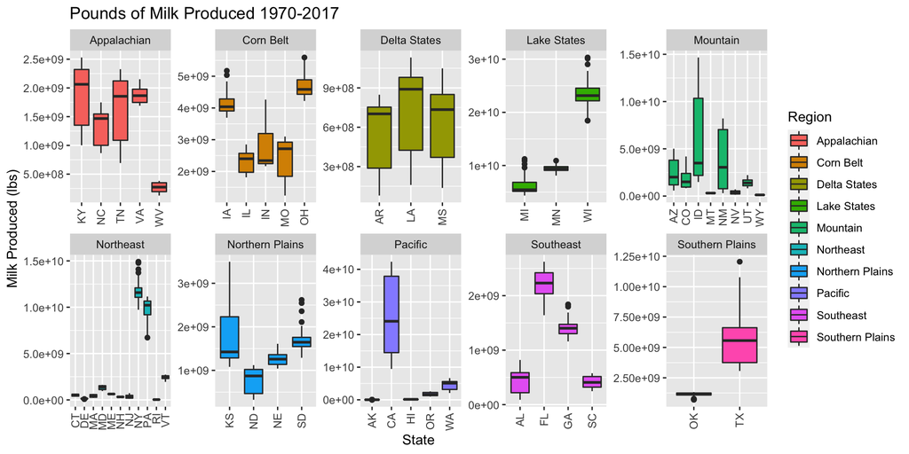

```r
# Summary Boxplots Milk Production by State

# Add column with state abbreviations for labeling
milk_plot_data = state_milk_production
for (i in 1:nrow(milk_plot_data)) {
  milk_plot_data[i,'state_abb'] = state.abb[which(state.name == milk_plot_data$state[i])]
}

ggplot(milk_plot_data, aes(x = state_abb, y = milk_produced, fill = region)) +
  geom_boxplot() +
  labs(x = 'State', y = 'Milk Produced (lbs)', title = 'Pounds of Milk Produced 1970-2017', fill = 'Region') +
  theme(axis.text.x = element_text(angle = 90, vjust = 0.5, hjust=1)) +
  facet_wrap(~region, scales='free', nrow = 2, ncol = 5)
```

This R chunk is used for calculating summary statistics by year.

```r
# Preparing summary statistics by year
year_df = pivot_wider(state_milk_production, names_from = year, values_from = milk_produced)

year_stats = matrix(data = NA, nrow = (ncol(year_df) - 2), ncol = 6)
cols = c('mean', 'median', 'standard deviation', 'minimum', 'maximum', 'sample size')
colnames(year_stats) = cols
year_stats_rows = c()
j = 1

for (i in 3:(ncol(year_df))) {
  year_stats_rows = append(year_stats_rows, colnames(year_df)[i])
  year_stats_data = as.numeric(as.matrix(year_df[i]))
  year_stats[j, 'mean'] = mean(year_stats_data)
  year_stats[j, 'median'] = median(year_stats_data)
  year_stats[j, 'standard deviation'] = sd(year_stats_data)
  year_stats[j, 'minimum'] = min(year_stats_data)
  year_stats[j, 'maximum'] = max(year_stats_data)
  year_stats[j, 'sample size'] = length(year_stats_data)

  j = j + 1
}

rownames(year_stats) = year_stats_rows

# Summary Statistics Milk Production by Year
kable(signif(year_stats, digits = 3), caption = 'Summary Statistics of Milk Production by Year')
```

Summary Statistics of Milk Production by Year

|  | mean | median | standard deviation | minimum | maximum | sample size |
| --- | --- | --- | --- | --- | --- | --- |
| 1970 | 2.34e+09 | 1.22e+09 | 3.36e+09 | 1.9e+07 | 1.84e+10 | 50 |
| 1971 | 2.37e+09 | 1.22e+09 | 3.42e+09 | 1.7e+07 | 1.88e+10 | 50 |
| 1972 | 2.40e+09 | 1.24e+09 | 3.48e+09 | 1.8e+07 | 1.92e+10 | 50 |
| 1973 | 2.31e+09 | 1.15e+09 | 3.34e+09 | 1.8e+07 | 1.84e+10 | 50 |
| 1974 | 2.31e+09 | 1.16e+09 | 3.39e+09 | 1.8e+07 | 1.87e+10 | 50 |
| 1975 | 2.31e+09 | 1.14e+09 | 3.42e+09 | 1.7e+07 | 1.89e+10 | 50 |
| 1976 | 2.40e+09 | 1.20e+09 | 3.63e+09 | 1.6e+07 | 2.03e+10 | 50 |
| 1977 | 2.45e+09 | 1.21e+09 | 3.74e+09 | 1.6e+07 | 2.10e+10 | 50 |
| 1978 | 2.43e+09 | 1.18e+09 | 3.76e+09 | 1.5e+07 | 2.13e+10 | 50 |
| 1979 | 2.47e+09 | 1.18e+09 | 3.87e+09 | 1.3e+07 | 2.18e+10 | 50 |
| 1980 | 2.57e+09 | 1.24e+09 | 4.02e+09 | 1.3e+07 | 2.24e+10 | 50 |
| 1981 | 2.66e+09 | 1.31e+09 | 4.15e+09 | 1.3e+07 | 2.30e+10 | 50 |
| 1982 | 2.71e+09 | 1.32e+09 | 4.21e+09 | 1.4e+07 | 2.32e+10 | 50 |
| 1983 | 2.79e+09 | 1.37e+09 | 4.33e+09 | 1.4e+07 | 2.38e+10 | 50 |
| 1984 | 2.71e+09 | 1.22e+09 | 4.31e+09 | 1.4e+07 | 2.35e+10 | 50 |
| 1985 | 2.86e+09 | 1.32e+09 | 4.56e+09 | 2.2e+07 | 2.47e+10 | 50 |
| 1986 | 2.86e+09 | 1.33e+09 | 4.56e+09 | 3.2e+07 | 2.45e+10 | 50 |
| 1987 | 2.85e+09 | 1.30e+09 | 4.63e+09 | 3.5e+07 | 2.48e+10 | 50 |
| 1988 | 2.90e+09 | 1.32e+09 | 4.70e+09 | 3.1e+07 | 2.50e+10 | 50 |
| 1989 | 2.88e+09 | 1.33e+09 | 4.62e+09 | 2.3e+07 | 2.39e+10 | 50 |
| 1990 | 2.95e+09 | 1.41e+09 | 4.77e+09 | 1.7e+07 | 2.42e+10 | 50 |
| 1991 | 2.95e+09 | 1.43e+09 | 4.76e+09 | 1.3e+07 | 2.38e+10 | 50 |
| 1992 | 3.02e+09 | 1.48e+09 | 4.85e+09 | 1.2e+07 | 2.38e+10 | 50 |
| 1993 | 3.01e+09 | 1.48e+09 | 4.82e+09 | 1.2e+07 | 2.29e+10 | 50 |
| 1994 | 3.07e+09 | 1.51e+09 | 4.99e+09 | 1.3e+07 | 2.52e+10 | 50 |
| 1995 | 3.11e+09 | 1.51e+09 | 5.06e+09 | 1.2e+07 | 2.53e+10 | 50 |
| 1996 | 3.08e+09 | 1.48e+09 | 5.07e+09 | 1.4e+07 | 2.58e+10 | 50 |
| 1997 | 3.12e+09 | 1.44e+09 | 5.23e+09 | 1.5e+07 | 2.76e+10 | 50 |
| 1998 | 3.15e+09 | 1.41e+09 | 5.29e+09 | 1.4e+07 | 2.76e+10 | 50 |
| 1999 | 3.25e+09 | 1.42e+09 | 5.61e+09 | 1.4e+07 | 3.04e+10 | 50 |
| 2000 | 3.35e+09 | 1.45e+09 | 5.82e+09 | 1.3e+07 | 3.22e+10 | 50 |
| 2001 | 3.31e+09 | 1.40e+09 | 5.84e+09 | 1.4e+07 | 3.32e+10 | 50 |
| 2002 | 3.40e+09 | 1.39e+09 | 6.04e+09 | 1.8e+07 | 3.51e+10 | 50 |
| 2003 | 3.41e+09 | 1.39e+09 | 6.10e+09 | 1.7e+07 | 3.54e+10 | 50 |
| 2004 | 3.42e+09 | 1.38e+09 | 6.20e+09 | 1.5e+07 | 3.65e+10 | 50 |
| 2005 | 3.54e+09 | 1.38e+09 | 6.42e+09 | 1.4e+07 | 3.76e+10 | 50 |
| 2006 | 3.64e+09 | 1.35e+09 | 6.63e+09 | 1.0e+07 | 3.88e+10 | 50 |
| 2007 | 3.71e+09 | 1.32e+09 | 6.91e+09 | 9.0e+06 | 4.07e+10 | 50 |
| 2008 | 3.80e+09 | 1.28e+09 | 7.04e+09 | 7.0e+06 | 4.12e+10 | 50 |
| 2009 | 3.78e+09 | 1.30e+09 | 6.91e+09 | 6.0e+06 | 3.95e+10 | 50 |
| 2010 | 3.86e+09 | 1.28e+09 | 7.09e+09 | 7.0e+06 | 4.04e+10 | 50 |
| 2011 | 3.93e+09 | 1.28e+09 | 7.23e+09 | 7.0e+06 | 4.15e+10 | 50 |
| 2012 | 4.01e+09 | 1.30e+09 | 7.36e+09 | 6.0e+06 | 4.18e+10 | 50 |
| 2013 | 4.02e+09 | 1.26e+09 | 7.34e+09 | 3.0e+06 | 4.13e+10 | 50 |
| 2014 | 4.12e+09 | 1.29e+09 | 7.50e+09 | 4.0e+06 | 4.23e+10 | 50 |
| 2015 | 4.17e+09 | 1.34e+09 | 7.47e+09 | 4.0e+06 | 4.09e+10 | 50 |
| 2016 | 4.25e+09 | 1.33e+09 | 7.56e+09 | 4.0e+06 | 4.05e+10 | 50 |
| 2017 | 4.31e+09 | 1.34e+09 | 7.55e+09 | 3.0e+06 | 3.98e+10 | 50 |

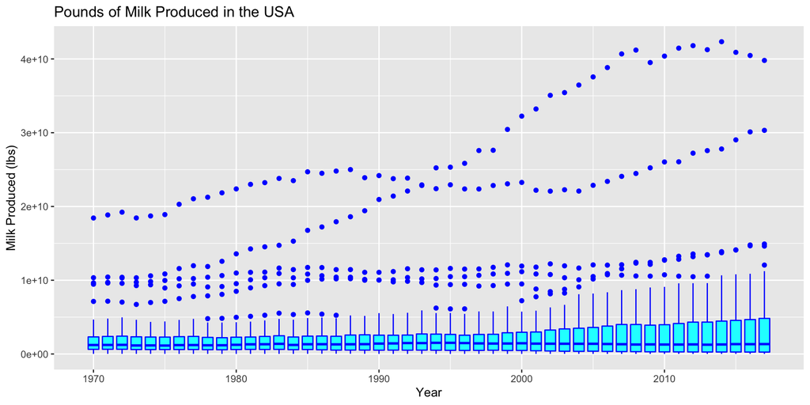

```r
# Summary Boxplots Milk Production by Year
ggplot(state_milk_production, aes(year, milk_produced, group = year)) +
  geom_boxplot(color = 'blue', fill = 'cyan') +
  labs(x = 'Year', y = 'Milk Produced (lbs)', title = 'Pounds of Milk Produced in the USA')
```

### Visual Representation of State Milk Production Across the Decades

In this section, I am providing several choropleth maps of the United States showing milk production in each state from 1970 to 2017. As shown in the maps, California and Wisconsin tended to produce more pounds of milk than other states.

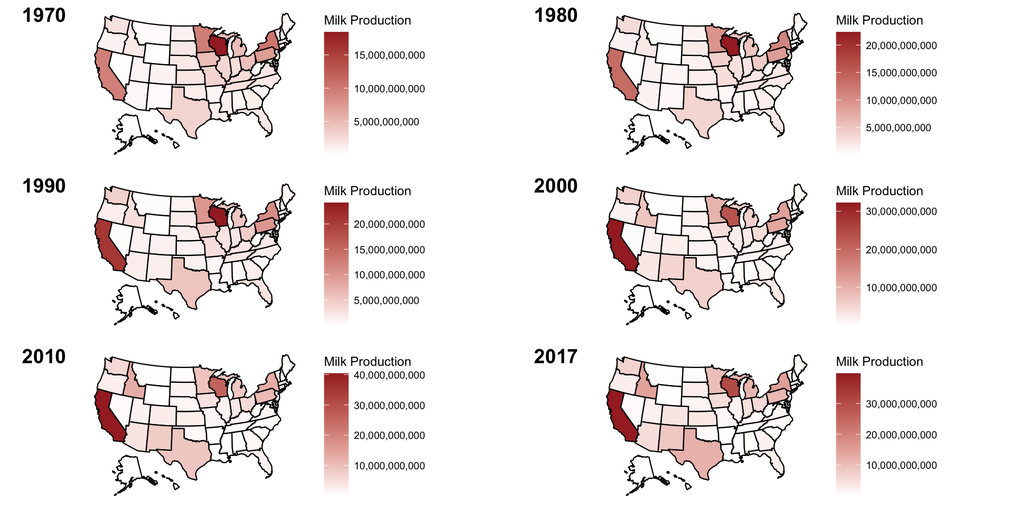

```r
# Organize states data so that year has columns with milk production
states_by_year = pivot_wider(state_milk_production, names_from = year, values_from = milk_produced)


# Create choropleth figures for milk production at each decade
fig70 = plot_usmap(data = states_by_year, values = '1970', color = 'black' ) +
  scale_fill_continuous(low = 'white', high = 'brown', name = 'Milk Production', label = scales::comma) +
  theme(legend.position = 'right')

fig80 = plot_usmap(data = states_by_year, values = '1980', color = 'black' ) +
  scale_fill_continuous(low = 'white', high = 'brown', name = 'Milk Production', label = scales::comma) +
  theme(legend.position = 'right')

fig90 = plot_usmap(data = states_by_year, values = '1990', color = 'black' ) +
  scale_fill_continuous(low = 'white', high = 'brown', name = 'Milk Production', label = scales::comma) +
  theme(legend.position = 'right')

fig00 = plot_usmap(data = states_by_year, values = '2000', color = 'black' ) +
  scale_fill_continuous(low = 'white', high = 'brown', name = 'Milk Production', label = scales::comma) +
  theme(legend.position = 'right')

fig10 = plot_usmap(data = states_by_year, values = '2010', color = 'black' ) +
  scale_fill_continuous(low = 'white', high = 'brown', name = 'Milk Production', label = scales::comma) +
  theme(legend.position = 'right')

fig17 = plot_usmap(data = states_by_year, values = '2017', color = 'black' ) +
  scale_fill_continuous(low = 'white', high = 'brown', name = 'Milk Production', label = scales::comma) +
  theme(legend.position = 'right')


# Plot the choropleths together
ggarrange(fig70, fig80, fig90, fig00, fig10, fig17,
          labels = c('1970', '1980', '1990', '2000', '2010', '2017'),
          ncol = 2, nrow = 3)
```

### Visual Representation of Milk Production by Region over Time

In this section, I am providing a graph containing the total pounds of milk produced in each region over the 47-year period of available data. Note that some regions had more states than other regions which could have affected the graph in this section. As shown below, the Lake States (MI, WI, MN) were consistently high producers of milk, and the production of milk in the Pacific states (WA, OR, CA, AK, HI) grew to become the highest regional producers of milk over time.

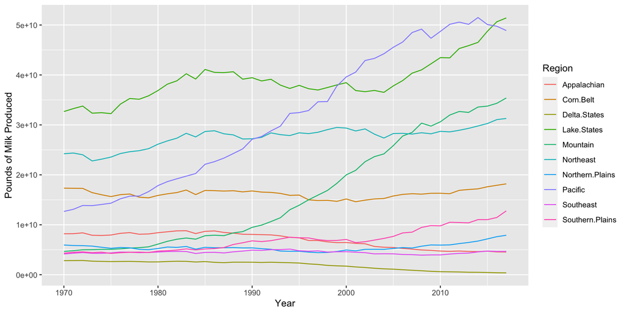

```r
interim = data.frame(year = state_milk_production$year,
                     state = state_milk_production$state,
                     milk_produced = state_milk_production$milk_produced)

states_by_states = pivot_wider(interim, names_from = state, values_from = milk_produced)

summed_regions = states_by_states %>%
  mutate(`Northeast` = `Maine` + `New Hampshire` + `Vermont` + `Massachusetts` + `Rhode Island` + `Connecticut` + `New York` + `New Jersey` + `Pennsylvania` + `Delaware` + `Maryland`) %>%
  mutate(`Lake States` = `Michigan` + `Wisconsin` + `Minnesota`) %>%
  mutate(`Corn Belt` = `Ohio` + `Indiana` + `Illinois` + `Iowa` + `Missouri`) %>%
  mutate(`Northern Plains` = `North Dakota` + `South Dakota` + `Nebraska` + `Kansas`) %>%
  mutate(`Appalachian` = `Virginia` + `West Virginia` + `North Carolina` + `Kentucky` + `Tennessee`) %>%
  mutate(`Southeast` = `South Carolina` + `Georgia` + `Florida` + `Alabama`) %>%
  mutate(`Delta States` = `Mississippi` + `Arkansas` + `Louisiana`) %>%
  mutate(`Southern Plains` = `Oklahoma` + `Texas`) %>%
  mutate(`Mountain` = `Montana` + `Idaho` + `Wyoming` + `Colorado` + `New Mexico` + `Arizona` + `Utah` + `Nevada`) %>%
  mutate(`Pacific` = `Washington` + `Oregon` + `California` + `Alaska` + `Hawaii`)



inter_total = summed_regions %>%
  mutate(`Total Milk` = `Northeast` + `Lake States` + `Corn Belt` + `Northern Plains` + `Appalachian` + `Southeast` + `Delta States` + `Southern Plains` + `Mountain` + `Pacific`)


milk_total = data.frame(year = inter_total$year,
                        total_milk = inter_total$`Total Milk`)



regional_milk = data.frame(year = summed_regions$year,
                           `Northeast` = summed_regions$Northeast,
                           `Lake States` = summed_regions$`Lake States`,
                           `Corn Belt` = summed_regions$`Corn Belt`,
                           `Northern Plains` = summed_regions$`Northern Plains`,
                           `Appalachian` = summed_regions$Appalachian,
                           `Southeast` = summed_regions$Southeast,
                           `Delta States` = summed_regions$`Delta States`,
                           `Southern Plains` = summed_regions$`Southern Plains`,
                           `Mountain` = summed_regions$Mountain,
                           `Pacific` = summed_regions$Pacific)


reg_milk = pivot_longer(regional_milk,
                        cols = c(Northeast, Lake.States, Corn.Belt, Northern.Plains, Appalachian, Southeast, Delta.States, Southern.Plains, Mountain, Pacific),
                        names_to = 'region',
                        values_to = 'milk_production')

ggplot(reg_milk, aes(x = year, y = milk_production, colour = region)) +
  geom_line() +
  labs(x = 'Year', y = 'Pounds of Milk Produced', colour = 'Region')
```

### Statistical Analyses of Milk Production

Here, I am performing a two-way ANOVA where the independent variables are state and year, and the dependent variable is pounds of milk produced. As shown by the p-values below, the differences between some of the means are statistically significant. However, the residuals of the ANOVA model are not normally distributed (as shown by the Shapiro-Wilk test) which may have had some impact on the ANOVA outcome. Further analysis using non-parametric tests would be recommended for this dataset.

```r
# Create ANOVA model and present the results

# ANOVA using state and year as independent variables
aov.milk = aov(milk_produced ~ state + year, data = state_milk_production)
summary(aov.milk)
```

```
##               Df    Sum Sq   Mean Sq F value Pr(>F)
## state         49 6.121e+22 1.249e+21   344.1 <2e-16 ***
## year           1 8.027e+20 8.027e+20   221.1 <2e-16 ***
## Residuals   2349 8.528e+21 3.630e+18
## ---
## Signif. codes:  0 '***' 0.001 '**' 0.01 '*' 0.05 '.' 0.1 ' ' 1
```

```r
milk.residuals = aov.milk$residuals
shapiro.test(milk.residuals)
```

```
##
##  Shapiro-Wilk normality test
##
## data:  milk.residuals
## W = 0.60048, p-value < 2.2e-16
```

## Fluid Milk Sales

The ‘fluid_milk_sales’ file contained three columns: year, milk type, and pounds of milk product sold per year. The years ranged from 1975 to 2017 and the milk types included whole milk, reduced fat (2%) milk, low fat (1%) milk, skim milk, flavored whole milk, flavored (not whole) milk, buttermilk, and eggnog. There was an additional column that included the total milk product.

### Summary Statistics of Fluid Milk Sales

```r
# Preparing summary statistics by fluid milk type
fluid_df = pivot_wider(fluid_milk_sales, names_from = milk_type, values_from = pounds)
fluid_df = fluid_df[-c(10)] # gets rid of total production column

fluid_stats = matrix(data = NA, nrow = (ncol(fluid_df) - 1), ncol = 6)
cols = c('mean', 'median', 'standard deviation', 'minimum', 'maximum', 'sample size')
colnames(fluid_stats) = cols
fluid_stats_rows = c()
j = 1


for (i in 2:(ncol(fluid_df))) {
  fluid_stats_rows = append(fluid_stats_rows, colnames(fluid_df)[i])
  fluid_stats_data = as.numeric(as.matrix(fluid_df[i]))
  fluid_stats[j, 'mean'] = mean(fluid_stats_data)
  fluid_stats[j, 'median'] = median(fluid_stats_data)
  fluid_stats[j, 'standard deviation'] = sd(fluid_stats_data)
  fluid_stats[j, 'minimum'] = min(fluid_stats_data)
  fluid_stats[j, 'maximum'] = max(fluid_stats_data)
  fluid_stats[j, 'sample size'] = length(fluid_stats_data)

  j = j + 1
}

rownames(fluid_stats) = fluid_stats_rows


# Summary Statistics of Milk Sales by Milk Type
kable(signif(fluid_stats, digits = 3), caption = 'Summary Statistics of Milk Sales by Milk Type')
```

Summary Statistics of Milk Sales by Milk Type

|  | mean | median | standard deviation | minimum | maximum | sample size |
| --- | --- | --- | --- | --- | --- | --- |
| Whole | 2.16e+10 | 1.87e+10 | 6.71e+09 | 1.39e+10 | 3.62e+10 | 43 |
| Reduced Fat (2%) | 1.67e+10 | 1.76e+10 | 2.94e+09 | 8.73e+09 | 1.99e+10 | 43 |
| Low Fat (1%) | 5.43e+09 | 5.82e+09 | 1.63e+09 | 2.74e+09 | 7.81e+09 | 43 |
| Skim | 5.95e+09 | 6.36e+09 | 2.48e+09 | 2.45e+09 | 9.20e+09 | 43 |
| Flavored (Whole) | 8.22e+08 | 7.49e+08 | 2.45e+08 | 5.39e+08 | 1.48e+09 | 43 |
| Flavored (Not Whole) | 2.43e+09 | 2.08e+09 | 1.13e+09 | 7.19e+08 | 4.04e+09 | 43 |
| Buttermilk | 7.36e+08 | 7.11e+08 | 2.15e+08 | 4.53e+08 | 1.05e+09 | 43 |
| Eggnog | 1.21e+08 | 1.23e+08 | 1.96e+07 | 7.60e+07 | 1.53e+08 | 43 |

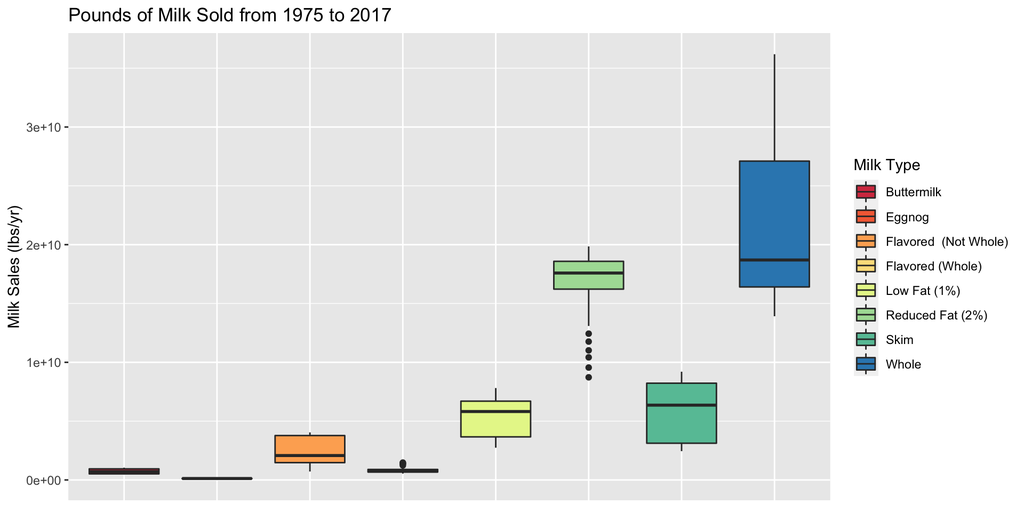

```r
# Summary Boxplots Milk Sales by Milk Type
milk_type_graph_data = subset(fluid_milk_sales, milk_type != 'Total Production')
  # Get rid of Total Production data

ggplot(milk_type_graph_data, aes(milk_type, pounds, group = milk_type, fill = milk_type)) +
  geom_boxplot() +
  labs(y = 'Milk Sales (lbs/yr)', title = 'Pounds of Milk Sold from 1975 to 2017', fill = 'Milk Type') +
  theme(axis.text.x = element_blank(),
        axis.title.x = element_blank(),
        axis.ticks.x = element_blank()) +
  scale_fill_brewer(palette = 'Spectral')
```

### Visual Representation of Fluid Milk Sales

In this section, I am using a stacked bar chart to show the proportions of each type of milk that were produced from 1975 to 2017.

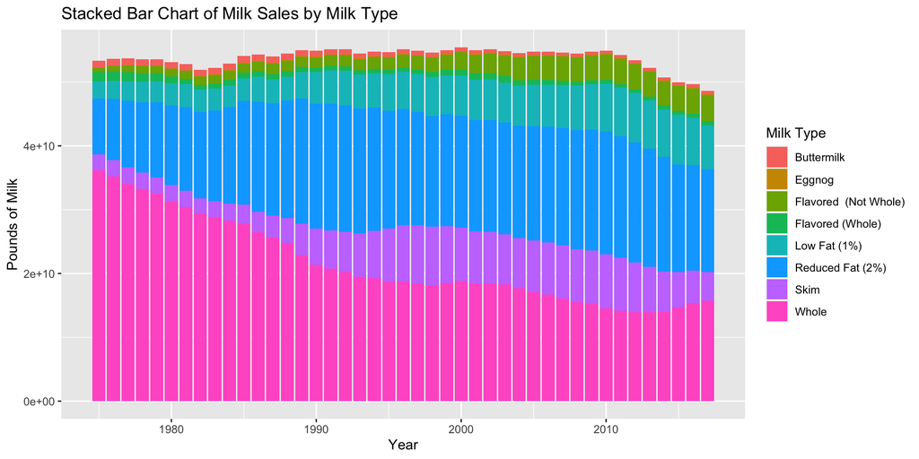

```r
graph_data = filter(fluid_milk_sales, milk_type != 'Total Production')


ggplot(graph_data, aes(x = year, y = pounds, fill = milk_type)) +
  geom_bar(position = 'stack', stat = 'identity') +
  labs(title = 'Stacked Bar Chart of Milk Sales by Milk Type', x = 'Year', y = 'Pounds of Milk', fill = 'Milk Type')
```

### Statiscal Analyses of Fluid Milk Sales

Here, I am performing a two-way ANOVA where the independent variables are milk type and year, and the dependent variable is pounds of milk sold per year. As shown by the p-values below, milk sales among milk type are statistically different, but milk sales across the years are not. However, the residuals of the ANOVA model are not normally distributed (as shown by the Shapiro-Wilk test) which may have had some impact on the ANOVA outcome. Further analysis using non-parametric tests would be recommended for this dataset.

```r
milk_type_stats_data = subset(fluid_milk_sales, milk_type != 'Total Production')
  # Get rid of total proudction

# ANOVA using milk type and year as independent variable
aov.milk_type = aov(pounds ~ milk_type + year, data = milk_type_stats_data)
summary(aov.milk_type)
```

```
##              Df    Sum Sq   Mean Sq F value Pr(>F)
## milk_type     7 1.961e+22 2.801e+21 349.702 <2e-16 ***
## year          1 6.203e+17 6.203e+17   0.077  0.781
## Residuals   335 2.683e+21 8.010e+18
## ---
## Signif. codes:  0 '***' 0.001 '**' 0.01 '*' 0.05 '.' 0.1 ' ' 1
```

```r
milk_type.residuals = aov.milk_type$residuals
shapiro.test(milk_type.residuals)
```

```
##
##  Shapiro-Wilk normality test
##
## data:  milk_type.residuals
## W = 0.83961, p-value < 2.2e-16
```

## Milk Data Conclusions

```r
write.table(state_stats[1:50,1], file = 'mean_milk_production_by_state.txt')
write.table(year_stats[1:48, 1], file = 'mean_milk_proudction_by_year.txt')
write.table(fluid_stats[1:8, 1], file = 'mean_milk_sales_by_type.txt')
```